# Chi-square

Mike Hitchman

12/06/2021

# 1. Testing Goodness of Fit

## The Scene

Suppose we want to test whether a particular probability model is a good fit for a random process we’re studying. Perhaps we’re wondering if our **lucky 6 sided die** is really fair. By fair, we mean that in the long run we would roll all values with equal probability. Put yet another way, we’re wondering if the probability model for the die looks like this:

| x | 1 | 2 | 3 | 4 | 5 | 6 |
| --- | --- | --- | --- | --- | --- | --- |
| p(x) | 1/6 | 1/6 | 1/6 | 1/6 | 1/6 | 1/6 |

How do we investigate this question? We roll. A lot. Let’s say we roll 600 times, and obtain these counts:

| x | 1 | 2 | 3 | 4 | 5 | 6 |
| --- | --- | --- | --- | --- | --- | --- |
| observed count | 94 | 107 | 84 | 116 | 102 | 97 |

In 600 rolls, what would be the *expected* counts for each number? According to the ideal probability model, we would expect 600$\times$(1/6) = 100 ones, and 100 twos, etc. In other words, for 600 rolls, our expected counts are:

| x | 1 | 2 | 3 | 4 | 5 | 6 |
| --- | --- | --- | --- | --- | --- | --- |
| expected count | 100 | 100 | 100 | 100 | 100 | 100 |

## The chi-square statistic

**Key Question**:  
Do our observed counts differ from the expected counts dramatically enough for us to conclude that the die is not fair?

**Test Statistic**
We distill from these data a single number, a test statistic, that summarizes how much the observed counts deviate from the expected counts. We will denote this test statistic as $\chi^2$, after the Greek letter $\chi$, pronounced “kai”. Here is the formula for the test statistic we use in this goodness of fit setting:
$$\chi^2 = \sum_{i=1}^6 \frac{(O_i-E_i)^2}{E_i}$$

This formula asks us to do a lot. First we subtract each expected count from the corresponding observed count, then we square that difference and divide that by the expected count. Then we add up all these numbers. Here’s the calculation:

$$\small{
\frac{(94-100)^2}{100} + \frac{(107-100)^2}{100} + \frac{(84-100)^2}{100} + \frac{(116-100)^2}{100} + \frac{(102-100)^2}{100} + \frac{(97-100)^2}{100} }$$

And this sum is
$$0.36 + 0.49 + 2.56 + 2.56 + 0.04 + 0.09 = 6.1.$$

So we have summarized the degree to which the observed counts differed from the expected counts with this single number, $\chi^2 = 6.1.$

A few comments about this statistic:

1. The quantity $(O-E)^2$ is never negative, since it is a square, so $\chi^2$ is a sum of non-negative numbers. In short, $\chi^2 \geq 0$. Always.
2. The further an observed count is from an expected count, the bigger $(O-E)^2$ gets, and so the bigger $\chi^2$ gets.
3. Generally speaking, the larger $\chi^2$ is, the stronger the evidence provided by the sample that the die does not adhere to the fair probability model.

**Key Question (revisited)**  
Does our sample provide enough evidence to conclude the die is not fair? We are now in a position to tackle this question as follows: If we roll a fair die 600 times, how likely is it to get a $\chi^2$ statistic as extreme or more extreme than the one we observed (6.1)?

Let’s simulate!!!

First, we build ourselves a die in RStudio. We can simulate rolling a fair 6-sided die a bunch of times with the `sample()` function. The following code (a) defines a 6-sided die, (b) “rolls” the die 100 times and records the rolls in a vector called results, and (c) displays the results.

```r
die<-c(1,2,3,4,5,6)
results <- sample(die, 100, replace=T)
results
```

```
##   [1] 2 2 5 3 4 2 5 6 5 6 1 5 2 3 5 2 1 1 4 6 2 1 4 5 1 3 4 5 2 2 6 6 6 3 5 6 6
##  [38] 3 2 3 1 1 5 3 3 1 2 5 2 5 5 4 2 3 6 2 1 1 4 4 2 2 6 4 1 5 3 3 6 2 1 1 3 3
##  [75] 1 3 5 4 2 5 4 1 3 6 6 6 2 2 5 6 6 5 3 4 6 2 4 2 2 6
```

And we can summarize how many times we rolled each number with the `table()` function:

```r
table(results)
```

```
## results
##  1  2  3  4  5  6
## 15 22 16 12 17 18
```

Nice!

In the RStudio help menu you can find out more about using the `sample()` function if you’re interested in adapting it to other scenarios, such as rolling 20-sided dice in Dungeons & Dragons when confronted with a demogorgon.

Ok, now we can run our simulation with the following code.

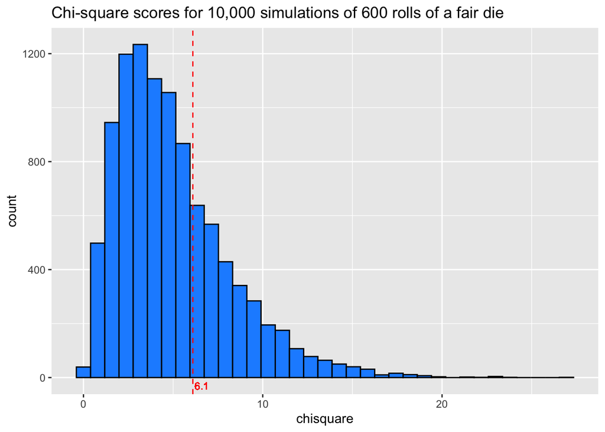

```r
n=600 #number of rolls in the actual game.

expected <- c(100,100,100,100,100,100) # This gives the expected counts for each value

## Running 10,000 simulations of this process: roll a die 600 times and compute the resulting chi-square statistic.
trials=10000
chi2 <- c() # we store the 10,000 chi-square scores in this vector
for (i in 1:trials){
  observed <- table(sample(c(1:6), n, replace=T))
  chi2[i] <- sum((observed-expected)^2/expected)
}

## Histogram of 10,000 simulated chi-square values, with our actual chi-square score of 6.1 marked with a vertical dashed line
sim.results <- data.frame(trial=c(1:trials),chisquare=chi2)
ggplot(sim.results)+
  geom_histogram(aes(x=chisquare),col="black",fill="dodgerblue",bins=35)+
  ggtitle("Chi-square scores for 10,000 simulations of 600 rolls of a fair die")+
  geom_vline(xintercept=6.1,col="red",linetype="dashed")+
  geom_text(x=6.6,y=-50,label = "6.1", size=3,col="red",vjust = -0.2)
```

From this histogram it doesn’t look as if getting a chi-square value of 6.1 (or more) is unusual at all for a fair die. In fact, we can easily check how often a fair die in our 10000 trials produced a chi-square value of 6.1 or greater:

```r
sum(chi2>=6.1)
```

```
## [1] 2941
```

**Conclusion**  
Our simulation shows that if we roll a fair die 600 times and then compute the chi-square value, we would obtain a value at least as big as 6.1 with probability about 0.294. Based on this simulation, seeing a test statistic of $\chi^2 = 6.1$ is not statistically significant (P = 0.294) - we do not have reason to reject the notion that the die is fair.

Note: The probability 0.294 is the p-value for the test of significance we’ve essentially been doing in this example.

# 2. The $\chi^2$ density curve

The histogram above is modeled by a theoretical density curve which is called a chi-square distribution (which is why we called the test statistic above a chi-square score :)).

The $\chi^2$ distribution looks skewed right.

The $\chi^2$ distribution is not a bell curve!

The $\chi^2$ distribution does not take any negative values.

The $\chi^2$ distribution is a new density curve for us, taking its rightful place alongside the standard normal curve $N(0,1)$ and the $t$-distributions as an important density curve in statistics. Here’s the density curve that our simulation above approximates:

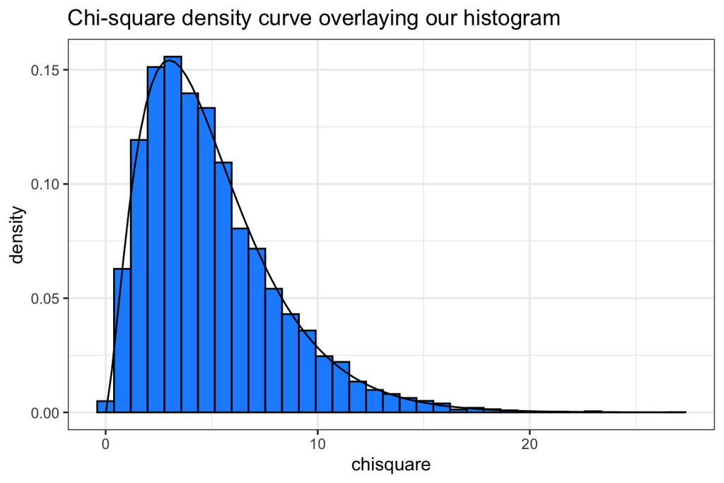

```r
ggplot(sim.results)+
  geom_histogram(aes(x=chisquare,y=..density..),col="black",fill="dodgerblue",bins=35)+
  ggtitle("Chi-square density curve overlaying our histogram")+
  stat_function(fun = dchisq, args = list(df = 5))+
  theme_bw()
```

## Degrees of freedom

The $\chi^2$ distribution, like the $t$-distribution, is actually a family of distributions, and each member in the family is specified by a *degrees of freedom*.

**In a chi-square goodness of fit test, the test statistic lives in a chi-square distribution with $n-1$ degrees of freedom, where $n$ is the number of values occurring in the probability model under consideration.**

Below are three chi-square density curves, one with 2 degrees of freedom, one with 5 degrees of freedom (this is the one we apply to our fair die model, since the die has 6 possible values), and one with 10 degrees of freedom.

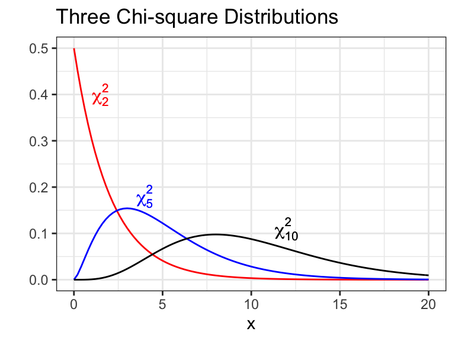

We remark that as the df gets larger, the values of $\chi^2_{\text{df}}$ also grow. For instance, essentially all of the $\chi^2_2$ distribution has value less than 10, whereas the $\chi^2_{10}$ takes values greater than 10 with some frequency. Furthermore, as the degrees of freedom gets larger, the $\chi^2_{\text{df}}$ curve gets less skewed. For instance, here’s a look at $\chi^2_{50}$. The values of this distribution largely range from 20 to 80, and the distribution is fairly symmetric:

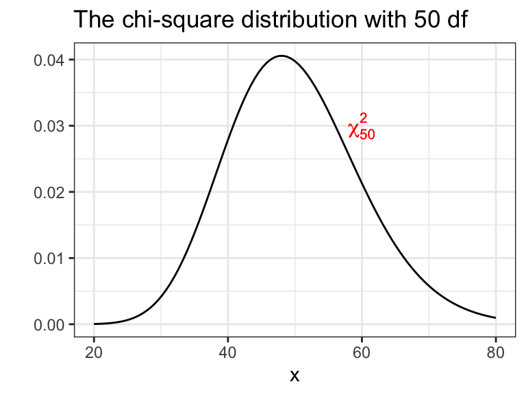

## Finding area

Let’s see, how have we done this with other distributions?

- `pnorm(z)` = proportion of the $N(0,1)$ distribution less than $z$
- `pt(t,df)` = proportion of the $t_{\text{df}}$ distribution less than $t$

So, yes,

- `pchisq(x,df)` gives the proportion of the $\chi^2_{\text{df}}$ distribution less than $x$, and
- `1 - pchsq(x,df)` gives the proportion of the $\chi^2_{\text{df}}$ distribution greater than $x$.

For instance, the proportion of the $\chi^2_5$ distribution greater than 6.1 is represented by the shaded region below

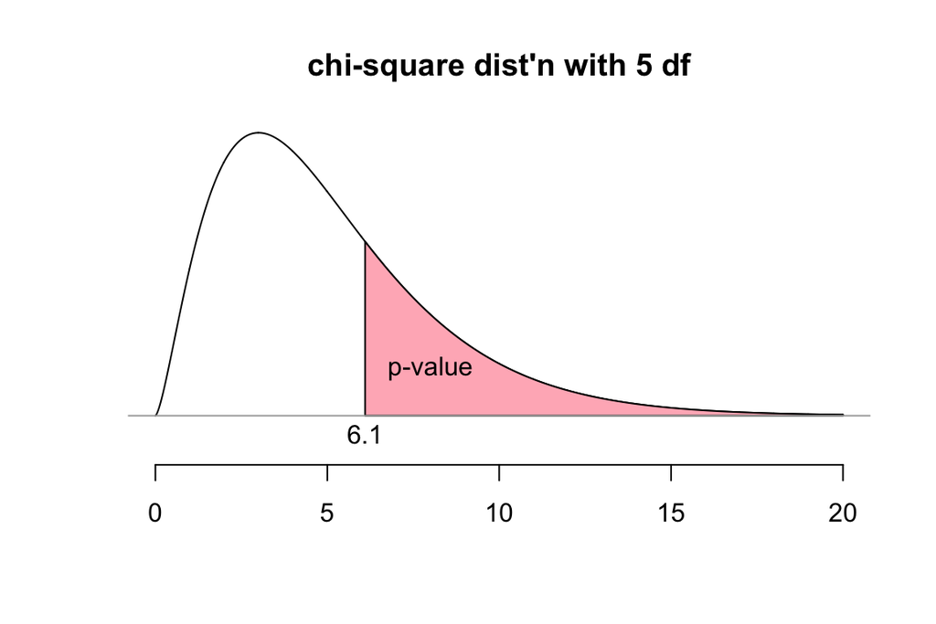

and this shaded region has area 0.2966098:

```r
1-pchisq(6.1,5)
```

```
## [1] 0.2966098
```

This area is very close to the proportion of our 10000 simulated chi-square values greater than or equal to 6.1!!

**When we do a chi-square test, the p-value will always be `1 - pchisq(test statistic, df)`**

## Conditions for using Chi-square

The chi-square density curve is an approximation to the distribution for the chi-square score. Is it always a good fit for this distribution? No, but the chi-square density curve is a reasonable model to use if both of these conditions are met:

1. None of the expected counts are less than 1.
2. No more 20% of the expected counts are less than 5.

In the example above, all of the expected counts are well over 5, so it is not surprising that the $\chi^2_5$ density is such a good fit with the histogram we obtained from our 10,000 simulations.

# 3. Goodness of Fit Example

## A special die

How well would the analysis above work to detect a die that is slightly different than fair? Consider the die below having a slightly “imbalanced” probability model.

| x | 1 | 2 | 3 | 4 | 5 | 6 |
| --- | --- | --- | --- | --- | --- | --- |
| p(x) | 0.16 | 0.17 | 0.14 | 0.19 | 0.18 | 0.16 |

Notice that rolling a 4 is most likely (19% of the time), and 3 is least likely (at 14% of the time). The code below creates a die with these ‘weights’, rolls this die 600 times, and store the different rolls in a vector called `results``. I encourage you to roll this die in your own RStudio session, and follow along with the analysis. (Of course, your observed results will no doubt look somewhat different than mine.)

```r
die <- c(1,2,3,4,5,6)
weights <- c(.16,.17,.14,.19,.18,.16)
results <- sample(die,600,replace=T,prob=weights)
```

## State hypotheses

Let’s say that after rolling several times we suspect our special die might not not be completely balanced, and we want to run a significance test. So we conduct this test of significance:

- $H_o$: the die is fair. This means that for all six values 1,2,3,4,5,6, the probability of coming up is 1/6.
- $H_a$: the die is not fair.

## Consider the data

Observed counts:

```r
table(results)
```

```
## results
##   1   2   3   4   5   6
##  94 121  80 115 106  84
```

Remember, in this significance test we are assuming the die is fair, so over 600 rolls, the expected count for each value of the die is 100.

| x | 1 | 2 | 3 | 4 | 5 | 6 |
| --- | --- | --- | --- | --- | --- | --- |
| expected count | 100 | 100 | 100 | 100 | 100 | 100 |

Do the observed counts differ enough from the fair die expected counts for us to conclude the die is not fair?

## Using `chisq.test()`

The **test statistic**
The test statistic is the chi-square score obtained by adding up the six $(O-E)^2/E$ values:
$$\chi^2 = \sum \frac{(O-E)^2}{E}.$$

The **degrees of freedom**  
When testing goodness of fit, the test statistic lives in a chi-square distribution with $n-1$ degrees of freedom, where $n$ is the number of values in the probability distribution we’re testing the fit for.

In this example, we are rolling a die having 6 possible values, so the df = 5.

The **p-value**  
This is the proportion of the $\chi^2_5$ distribution greater than the value of the test statistic.

R has a nice built-in function for doing the entire test of significance in one fell swoop, the `chisq.test()` command.

```r
xsq<-chisq.test(x=table(results),p=c(1/6,1/6,1/6,1/6,1/6,1/6))
```

We stored the results of the test in an object we call `xsq`. We can extract various items related to the test including:

- `xsq$expected` which gives the expected counts.
- `xsq$statistic` gives the value of the chi-square score
- `xsq$p.value` gives the p-value
- And just running the `chisq.test` without saving it to a name first will produce a nice summary of the test.

```r
chisq.test(x=table(results),p=c(1/6,1/6,1/6,1/6,1/6,1/6))
```

```
##
##  Chi-squared test for given probabilities
##
## data:  table(results)
## X-squared = 13.94, df = 5, p-value = 0.016
```

## State conclusion

The chi-square score from the data is $\chi^2 =$ 13.94, and the p-value will be the area above this value in the $\chi^2_5$ distribution as pictured below:

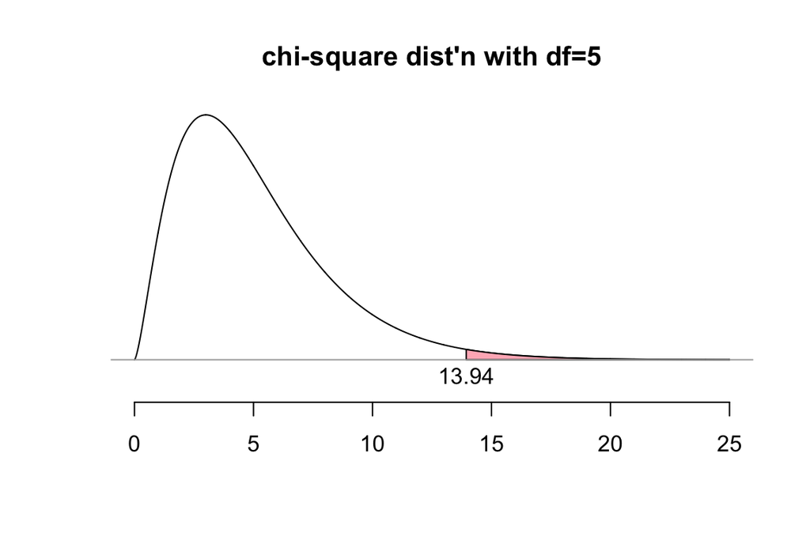

This area equals 0.016, the p-value for the test.

If the die is fair, we would observe results as extreme or more extreme than the results we saw with probability 0.016. Is this probability low enough for you to be convinced to reject the null hypothesis and conclude the die is not fair, but instead super special? :)

# 4. Testing Independence

## The Scene

Suppose we have two categorical variables and we want to see if they’re associated or whether they’re independent.

For instance, we might ask an independent sample of Linfield students the following question:

If you could choose one of the following accomplishments for your life, which would you choose:

- To win an Olympic gold medal
- To win a Nobel Prize
- To win an Academy Award
- To become President of the United States

Is a student’s answer to this question independent of their choice of major at Linfield, or are these two variables related in some way?

We ask this question to a simple random sample of 104 students, and we also ask them where they intend to earn their (first) major: School of Nursing, School of Business, or the College of Arts and Sciences (CAS).

Here’s a look at the first eight rows of the data:

```r
head(df,8)
```

```
##     degree achieve
## 1      cas   oscar
## 2 business   nobel
## 3 business   nobel
## 4      cas   oscar
## 5      cas    gold
## 6  nursing   nobel
## 7 business    gold
## 8  nursing    gold
```

We summarize all the results with a **two-way table**, an indispensible data visualization tool when comparing two categorical variables.

```r
table(df)
```

```
##           achieve
## degree     gold nobel oscar pres
##   business   12     5     9    8
##   cas         7    12     7    5
##   nursing     9    14    11    5
```

Is the location of a person’s intended major associated with their chosen achievement?

### Hypotheses

$H_o$: There is no association between the location of a person’s intended major at Linfield and their answer to the achievement question.

$H_a$: There is an association between these categorical variables.

### Game plan

The game plan in any test of significance is to do this: assume the null hypothesis is true and determine the likelihood of having observed such extreme data in the direction of the alternative.

So, we assume no association between degree and achievement here.

This assumption allows us to determine “expected” responses for each cell in the two-way table. Let’s see how to do this by considering the first cell (business majors choosing gold medal).

First, let’s determine the overall sample proportion of students who choose gold medal as their preferred achievement. For this we need to know how many students were asked in total, as well as how many students overall answered gold medal. To find these totals we ask R to give us all row and column totals of the table, which we can do with the `addmargins()` command.

```r
addmargins(table(df))
```

```
##           achieve
## degree     gold nobel oscar pres Sum
##   business   12     5     9    8  34
##   cas         7    12     7    5  31
##   nursing     9    14    11    5  39
##   Sum        28    31    27   18 104
```

So the sample proportion of all students who choose gold medal is 28/104 $\approx$ 0.269. If this same percentage of the 34 business majors in the survey had chosen gold medal, how many people would that have been? The answer is:
$$34\cdot\frac{28}{104} \approx 9.15.$$

In other words, if there is no association between the two variables, the *expected* number of business majors who would have selected gold medal is about 9.15. The actual number of business majors choosing gold medal was 12.

We remark that the expected count for the (business,gold) cell was found by doing the following:
$$\text{expected count} = \frac{(\text{row total })\cdot (\text{column total})}{\text{overall total}}.$$

This pattern holds for every cell in the two-way table. We make this precise with some notation.

Let $O_{i,j}$ denote the observed count in row $i$, column $j$ of the two-way table. So $O_{1,1} = 12$, which represents the (business,gold) combination we just considered. Meanwhile $O_{3,2} = 14$ is the observed number of nursing students who chose Nobel Prize.

Similarly, we can let $E_{i,j}$ denote the expected count in row $i$, column $j$ of the two-way table assuming no association between the two variables. What we worked out above is that $E_{i,j}$ is given by the formula
$$E_{i,j} = \frac{(\text{row i total})\cdot (\text{column j total})}{\text{overall total}}.$$
Here’s a table showing how to compute the expected count for each of the 12 cells.

$$\begin{array}{l | c c c c | c }
\text{Expected counts} & \text{gold} & \text{nobel} & \text{oscar} & \text{pres} & \text{sum} \\\hline
\text{business} & \frac{34\cdot 28}{104} & \frac{34\cdot 31}{104} & \frac{34\cdot 27}{104} & \frac{34\cdot 18}{104} & 34 \\
\text{cas} & \frac{31\cdot 28}{104} & \frac{31\cdot 31}{104} & \frac{31\cdot 27}{104} & \frac{31\cdot 18}{104} & 31 \\
\text{nursing} & \frac{39\cdot 28}{104} & \frac{39\cdot 31}{104} & \frac{39\cdot 27}{104} & \frac{39\cdot 18}{104} & 39 \\\hline
\text{sum} & 28 & 31 & 27 & 18 & 104 \\
\end{array}$$

And here are the values of the **expected counts**:

```
##           achieve
## degree      gold nobel oscar pres
##   business  9.15 10.13  8.83 5.88
##   cas       8.35  9.24  8.05 5.37
##   nursing  10.50 11.62 10.12 6.75
```

We often see expected counts in parentheses next to observed counts in a single two-way table:

$$\begin{array}{l | c c c c | }
\text{observed (expected)} & \text{gold} & \text{nobel} & \text{oscar} & \text{pres} \\\hline
\text{business} & 12~(9.15) & 5 ~(10.13) & 9 ~(8.83) & 8 ~(5.88)\\
\text{cas} & 7 ~(8.35) & 12~ (9.24) & 7~ (8.05) & 5~ (5.37) \\
\text{nursing} & 9~ (10.50) & 14~ (11.62) & 11~ (10.12) & 5~ (6.75)\\\hline
\end{array}$$

## The test statistic

As before, the chi-square test statistic is found by adding up all the $(O-E)^2/E$ terms:
$$\chi^2 = \sum_{\text{all cells}} \frac{(O_{i,j}-E_{i,j})^2}{E_{i,j}}.$$

So the chi-square test statistic in our example is the sum of the 12 values
$$\chi^2 = \frac{(12-9.15)^2}{9.15} + \frac{(5-10.13)^2}{10.13} + \frac{(9-8.83)^2}{8.83} + \cdots + \frac{(5-6.75)^2}{6.75},$$

which works out to $\chi^2$ = 6.69.

## degrees of freedom

**In a chi-square test of independence for two categorical variables, the test statistic lives in a chi-square distribution with $(r-1)\times(c-1)$ degrees of freedom, where $r$ and $c$ denote the number of rows and columns, respectively, in the two-way table.**

In our example the two-way table summarizing the two categorical variables has 3 rows and 4 columns, so our test statistic has $2\times 3 = 6$ degrees of freedom.

## The p-value.

Remember, $\chi^2$ is a single number that represents how different our observed data is from what we should have expected if there is no association between the two variables. The larger the test statistic, the greater the discrepancy between observed data and data we would expect if $H_o$ is true.

The p-value is the probability of getting a test statistic as big or bigger than the one we got. It is the area of this shaded region:

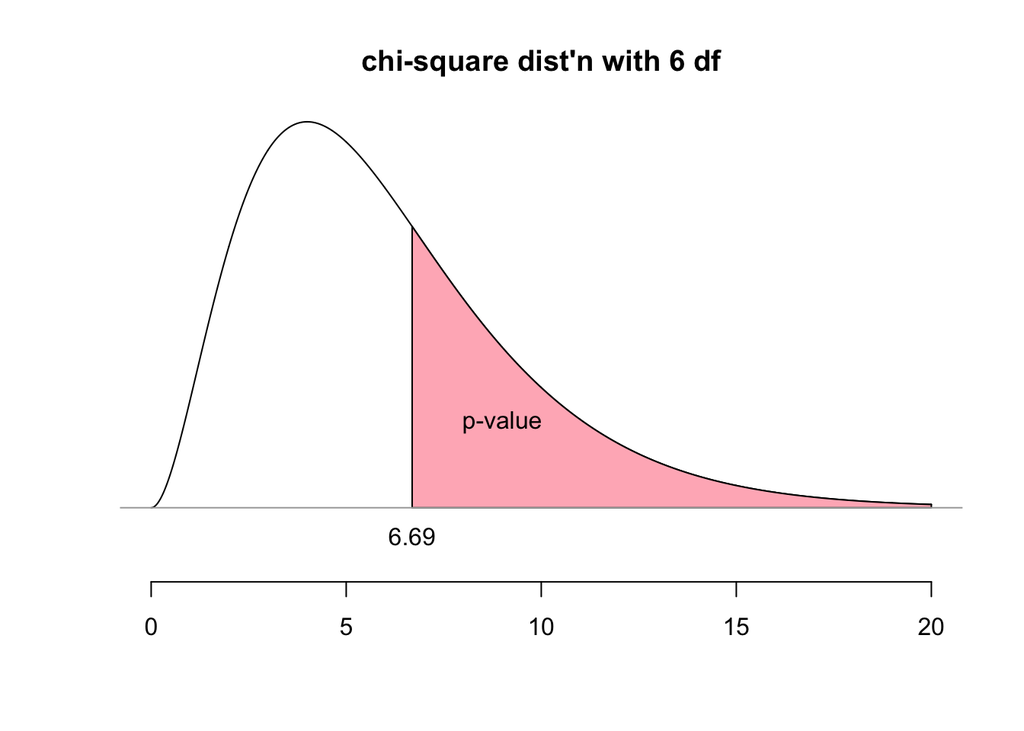

and this area equals:

```r
1 - pchisq(test.stat,6)
```

```
## [1] 0.350434
```

## Conclusion

If there is no association between a student’s intended major and their answer to the survey question, then the data we collected, or data even further away from what would be expected, would occur fairly often, with probability 0.35. This probability is not low enough to convince us that the null hypothesis is false.

We fail to reject the null hypothesis. Our sample does not provide sufficient evidence that a student’s intended major is associated with their choice of achievement in the survey question. Go `Cats!

## Doing the test in one fell swoop

Now that we’ve worked it out by hand, let’s crank out the result directly from the `chisq.test()` command. Notice that we do not enter the raw data (`df`), but rather the two-way table `table(df)` in the `'chisq.test()` command. Check out the chisq.test in the help menu for more details about this built in test.

```r
chisq.test(table(df))
```

```
##
##  Pearson's Chi-squared test
##
## data:  table(df)
## X-squared = 6.6816, df = 6, p-value = 0.3513
```

We remark that there is a slight difference in the value of $\chi^2$ (6.68 instead of 6.69) here from what we computed by hand. This difference is due to the fact that when we worked it out by hand above, we rounded each of the expected counts to two decimal places before calculating $\chi^2$.